# Demo distributions

Math 115 instructional

2017

# Introduction

For every distribution there are four commands. The commands for each distribution are prepended with a letter to indicate the functionality:

“d” returns the height of the probability density function  
“p” returns the cumulative density function  
“q” returns the inverse cumulative density function (quantiles)  
“r” returns randomly generated numbers

### We will look at the normal, chi squared, binomial, and t distributions.

# Normal

### Plot the normal distribution with mean 30 and standard deviation 8 over the interval from 0 to 60.

First create the xaxis to run from 0 to 60

```r
xaxis=seq(from=0,to=60,by=.05)
```

Now use dnorm to put in the yaxis values

```r
yaxis=dnorm(xaxis,mean=30,sd=8)
```

now plot

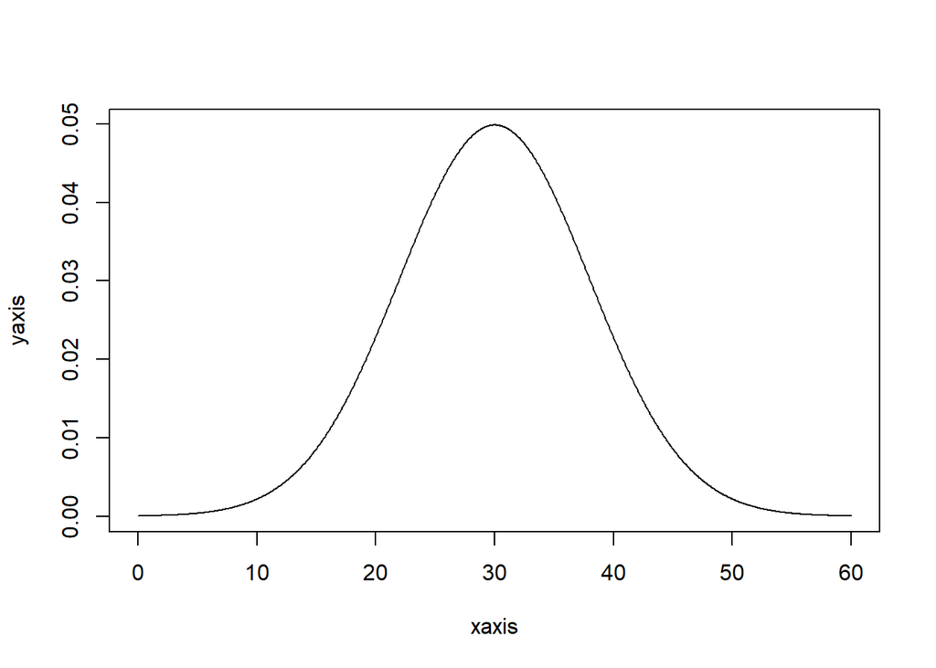

```r
plot(xaxis,yaxis,type="l")
```

now draw a vertical red line at 42

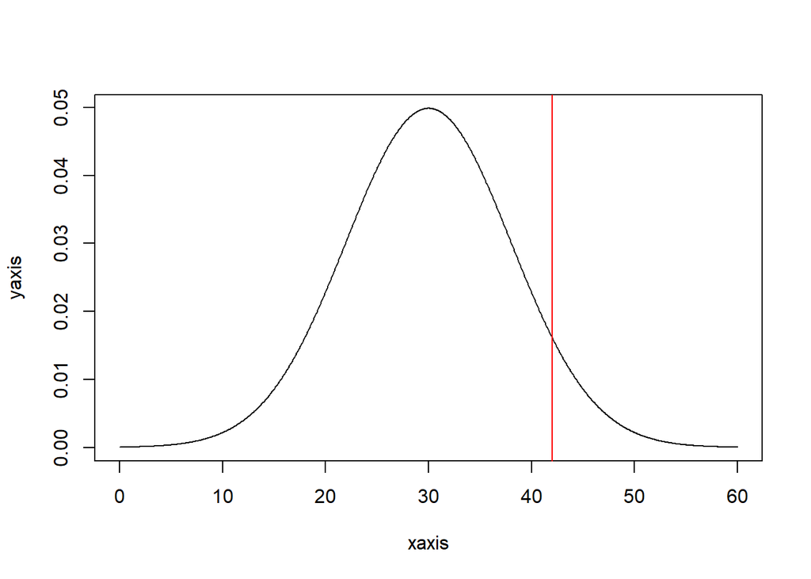

```r
plot(xaxis,yaxis,type="l")
abline(v=42,col="red")
```

# Try now with Chi Squared — plot a chisq variable with 7 degrees of freedom over the interval from 0 to 60

we can use the same xaxis variable

we will generate our y axis with dchisq

```r
chiyaxis=dchisq(xaxis,df=7)
```

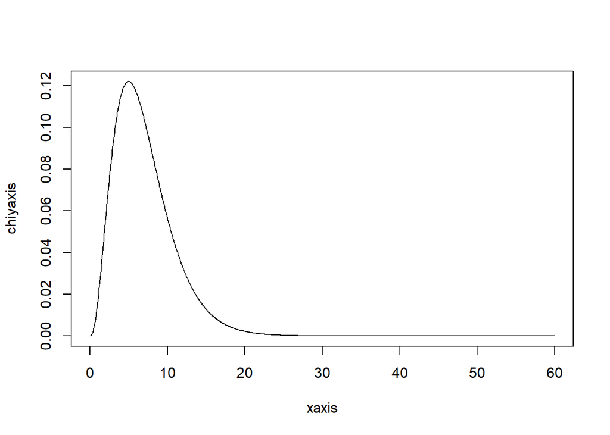

```r
plot(xaxis,chiyaxis,type="l")
```

Now suppose we had run a chisq.test on a data-set with 7 degrees of freedom and the value we got for chisq wa 23.

Draw a verticle red line on the distribution function.

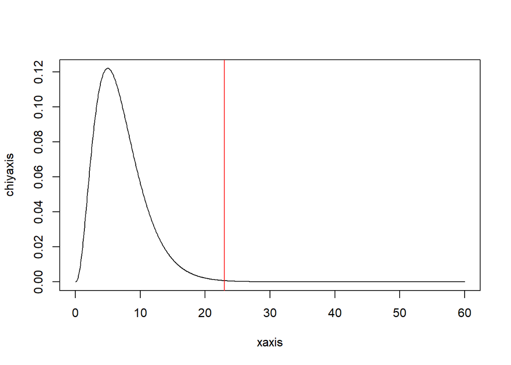

```r
plot(xaxis,chiyaxis,type="l")
abline(v=23,col="red")
```

what is the area to the left and right of the red line?

We calculate with pchisq

```r
(leftarea=pchisq(q=23,df=7))
```

```
## [1] 0.9982954
```

```r
(rightarea=pchisq(q=23,df=7,lower.tail = FALSE))
```

```
## [1] 0.001704608
```

Where should we draw the red line to have 95% on its left and 5% on its right?

We use qchisq for this

```r
point5pct=qchisq(p=.95,df=7)
```

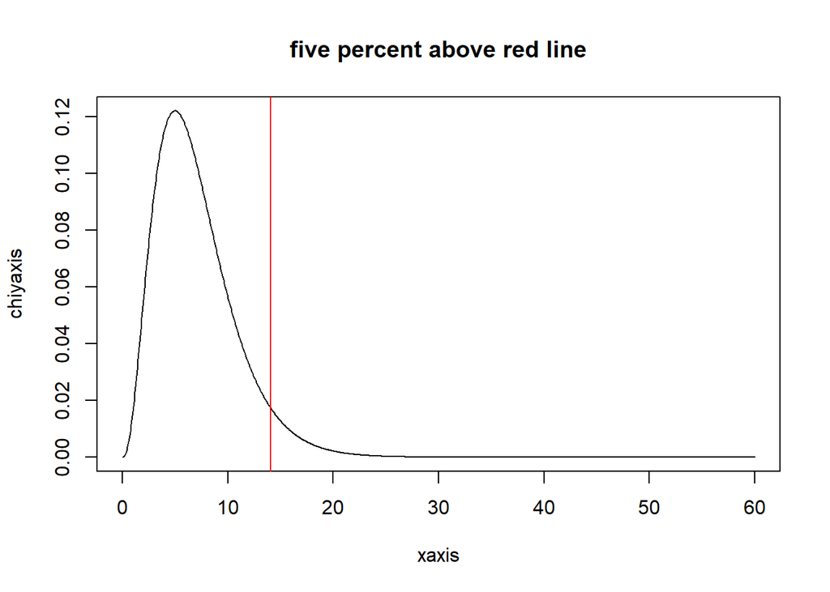

```r
plot(xaxis,chiyaxis,type="l",main="five percent above red line")
abline(v=point5pct,col="red")
```

## Challange — what is the area to the right of the red line you drew

## at 42 in the first plot??

# The Binomial Distribution

This models drawing a sample of a given size from a population where the probability of a single draw success is known.

plot the binomial distribution of drawing 40 things from a population where a single draw success is 1/6.

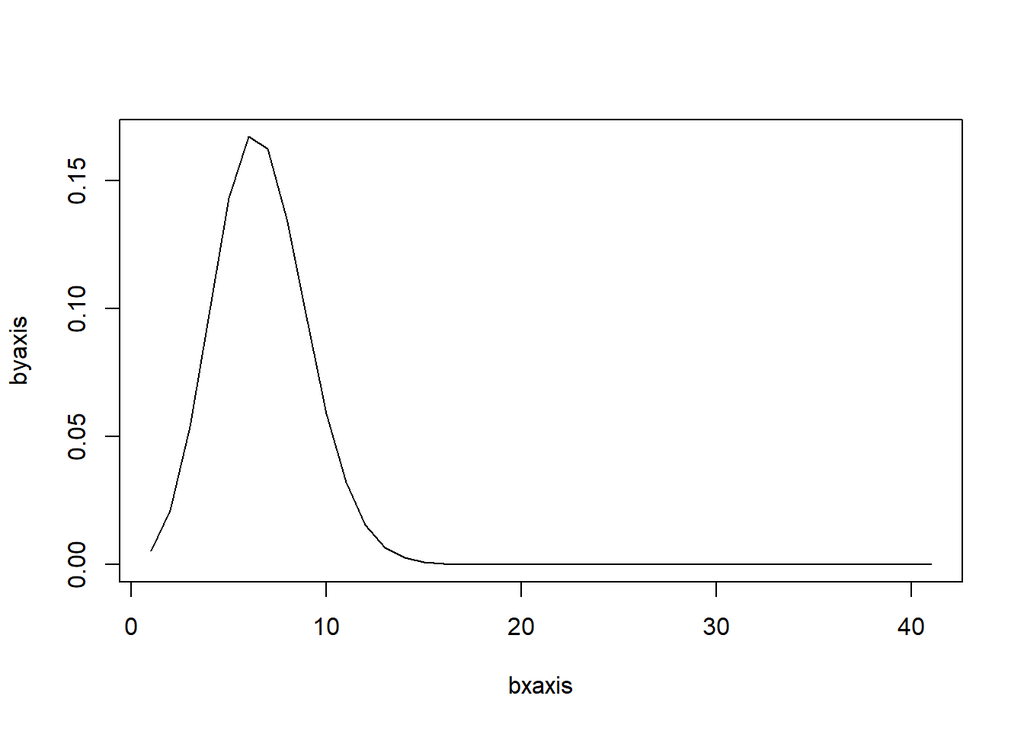

```r
bxaxis=seq(0:40)
byaxis=dbinom(bxaxis,size=40,prob=1/6)
plot(bxaxis,byaxis,type ="l" )
```

We know that binomial distributions have a mean of p*n (1/6* 40) or a bit less than 7 and a standard deviation of sqrt(p*q*n)  
about 2.4 — plot conforms

# Challange draw a t-distribution with 5 degrees of freedom over the xaxis from -8 to 8.

## Draw a vertical red line at the point where 30 percent of the area is left of your red line.

# Emperical Distribution Functions.

## We dont have the d,p,q,r functionality for data we sample or otherwise we collect.

Here I grab a 1000 point sample from a chisq distribution on 30 deg of freedom

```r
mysamp=rchisq(n=1000,df=30)
mydens=ecdf(mysamp)
plot(density(mysamp))
mydens(50)
```

```
## [1] 0.99
```

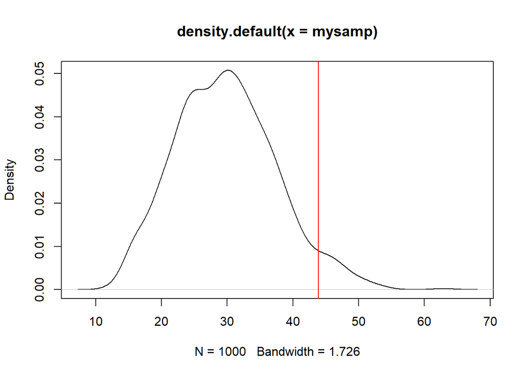

```r
#so mydens is acting like pnorm for normal
#what acts like qnorm here?

xx=quantile(mysamp,.95)
abline(v=xx,col="red")
```